# Лабораторная 2. Графика временных рядов

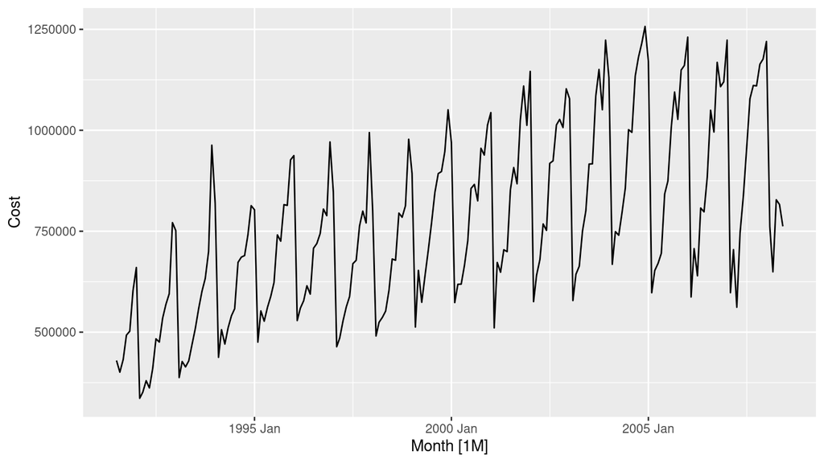

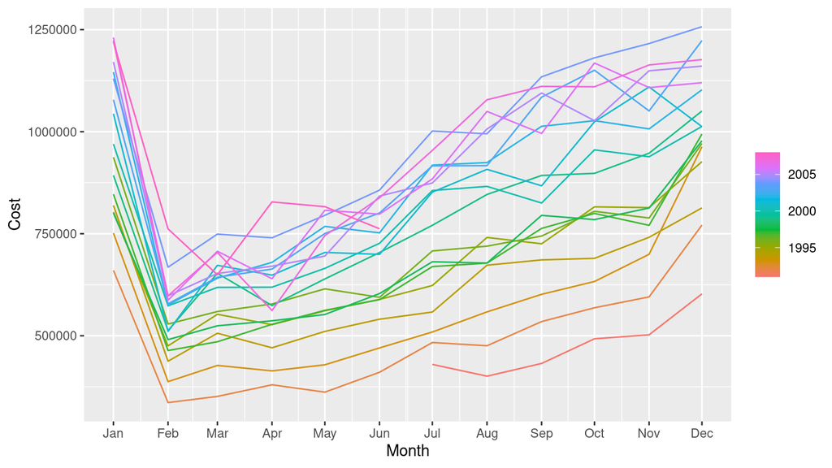

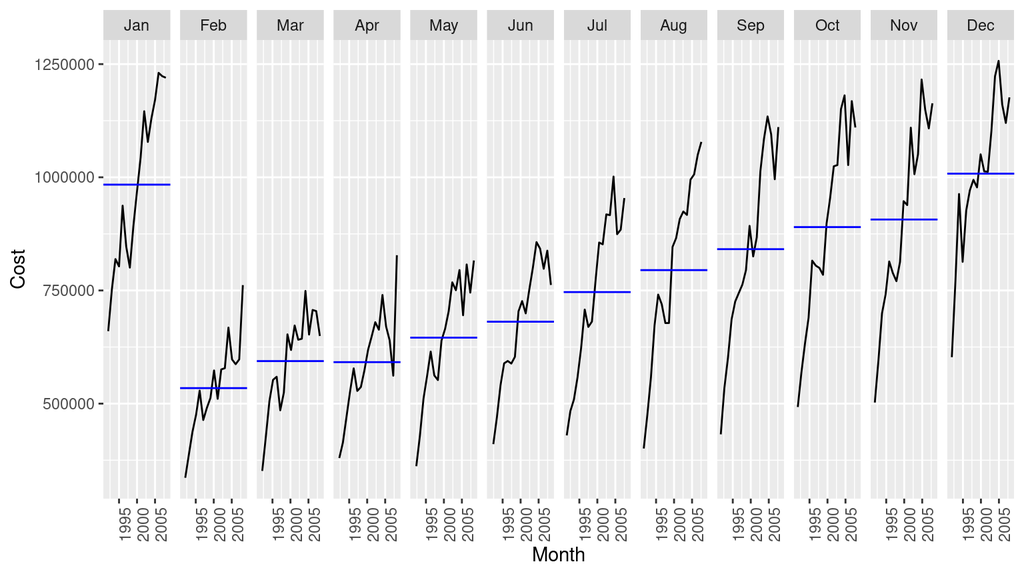

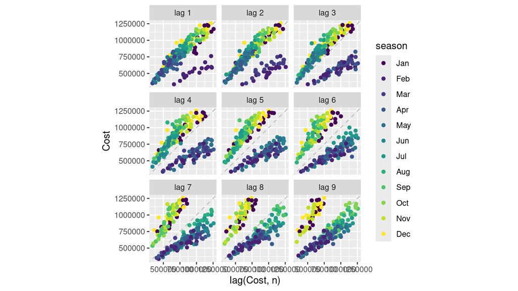

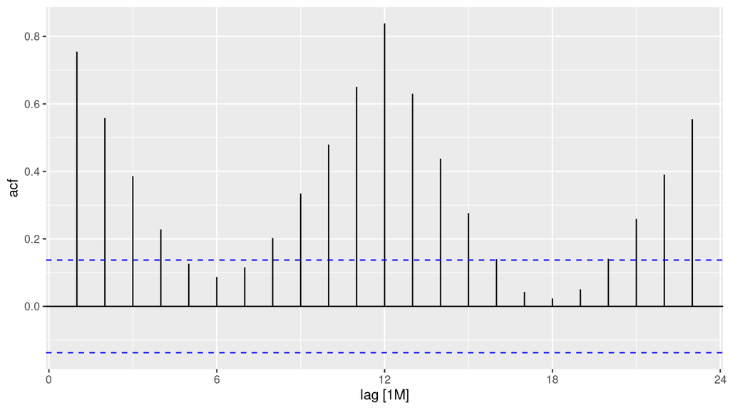

```r
explore(h02, Cost)
```

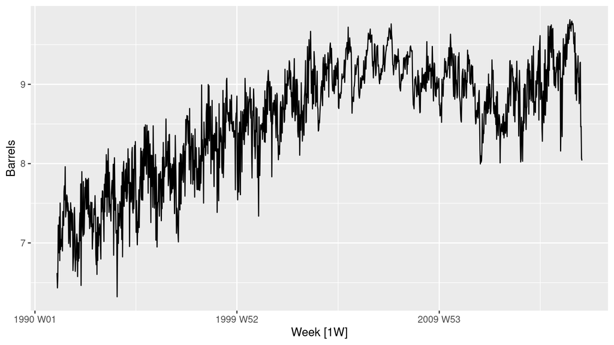

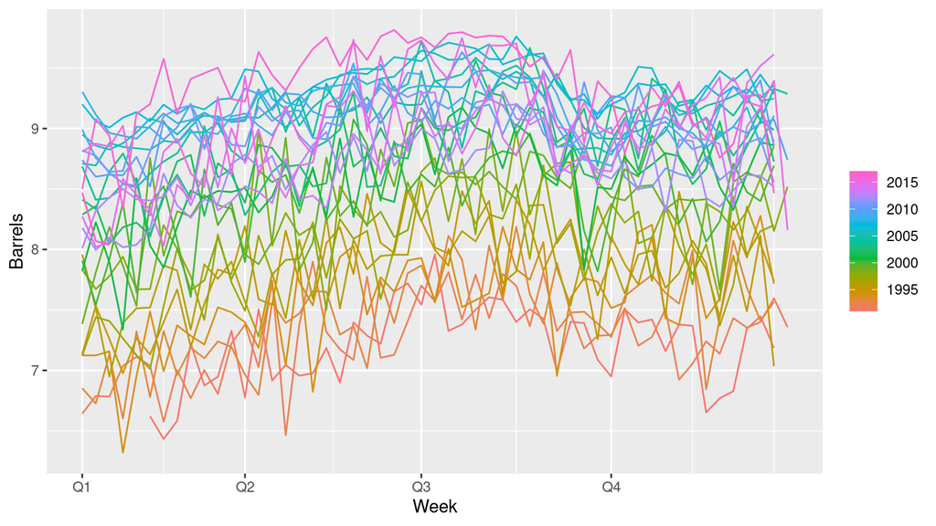

[figure not shown]

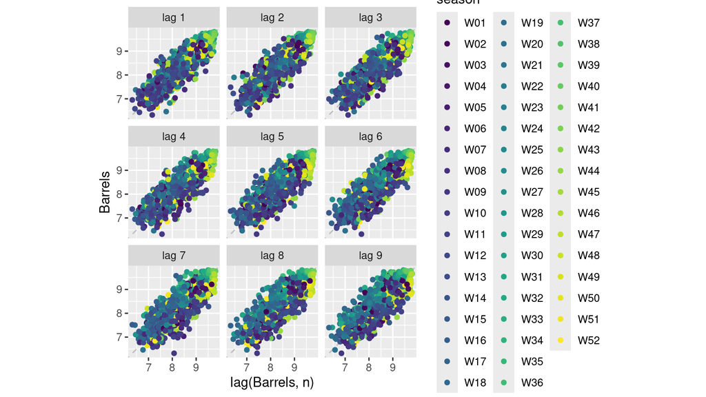

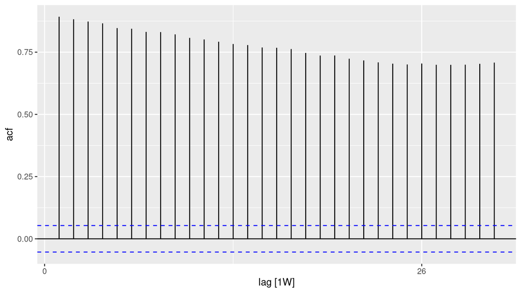

```r
explore(us_gasoline, Barrels)
```

Занятость и бензин растут и имеют год сезона. Кирпич — квартальная сезонность и обрыв ряда около 2005 года. Заяц — многолетний цикл около 10 лет, не календарный сезон. Расходы H02 растут, сезон есть, отдельные месяцы выбиваются.

## 9. Какой график к какой ACF

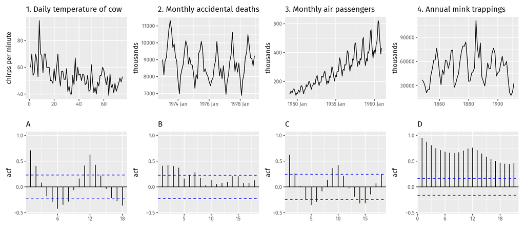

```r
knitr::include_graphics("acfguess.png")
```

Медленный спад ACF означает тренд или длинный цикл. Пики через фиксированный лаг означают сезон. Быстрый обрыв означает слабую память.

## 10. Свиньи, Victoria, 1990–1995

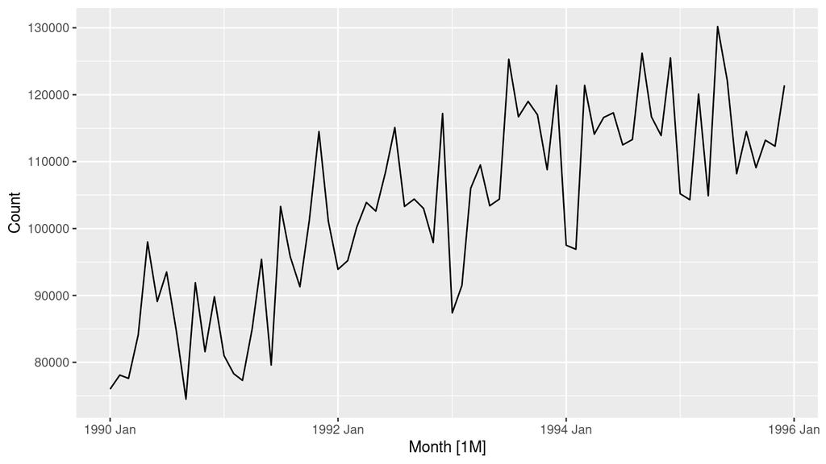

```r
pigs_short <- aus_livestock |>
  filter(Animal == "Pigs", State == "Victoria",
         year(Month) >= 1990, year(Month) <= 1995)
autoplot(pigs_short, Count)
```

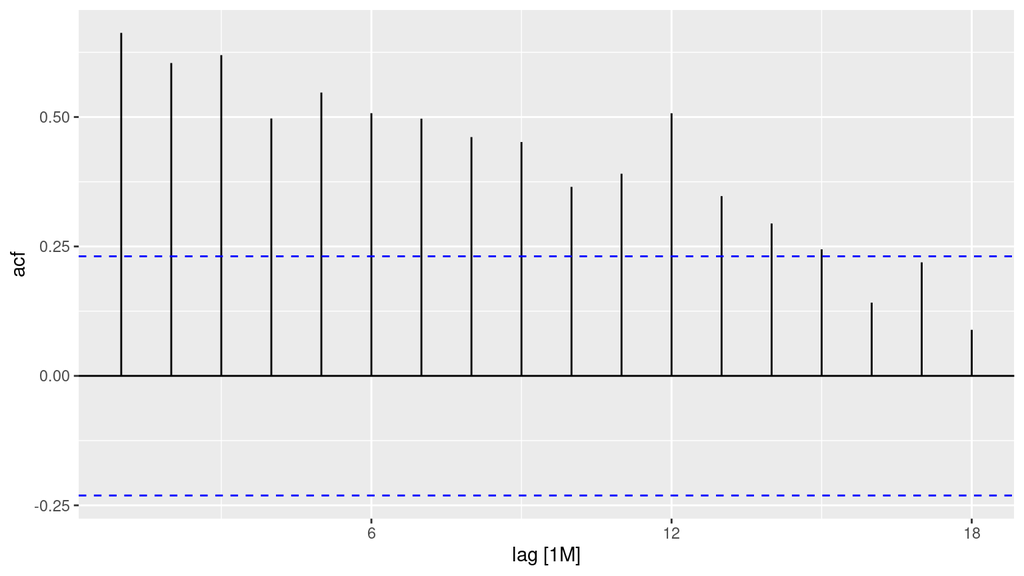

```r
pigs_short |> ACF(Count) |> autoplot()
```

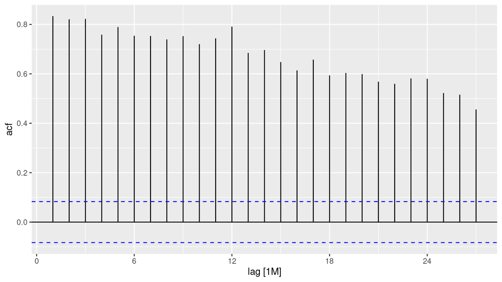

```r
pigs_all <- aus_livestock |>
  filter(Animal == "Pigs", State == "Victoria")
pigs_all |> ACF(Count) |> autoplot()
```

Это не белый шум: ACF не обрывается после лага 0, видна сезонность. На длинном ряде границы уже (они порядка $1/\sqrt{T}$), сезонные пики читаются увереннее.

## 11. Изменения цены Google

Индекс `Date` пропускает выходные и праздники, поэтому разность по календарю — не «вчерашний торговый день». Индекс заменяется номером торгового дня, и `difference()` считает изменение от предыдущей сессии.

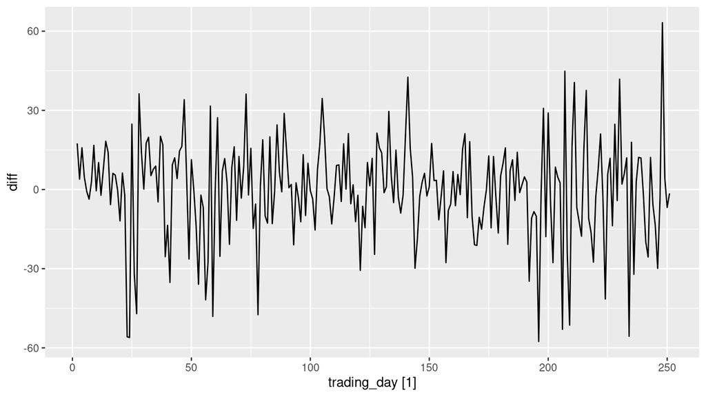

```r
dgoog <- gafa_stock |>
  filter(Symbol == "GOOG", year(Date) >= 2018) |>
  mutate(trading_day = row_number()) |>
  update_tsibble(index = trading_day, regular = TRUE) |>
  mutate(diff = difference(Close))
autoplot(dgoog, diff)
```

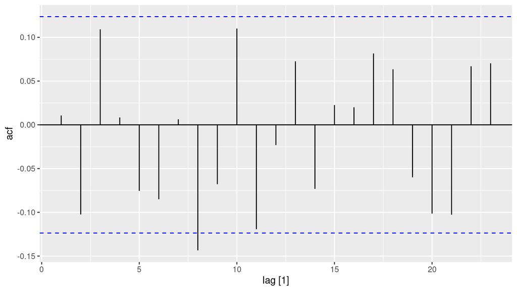

```r
dgoog |> ACF(diff) |> autoplot()
```

Изменения похожи на белый шум: почти все корреляции внутри границ. Небольшой выброс отдельных лагов для конечной выборки нормален.